Contents under Creative Commons BY 4.0 license and code under MIT license. © Julian Parra 2019. This material is part of the Master of Engineering program by Julian Parra at Universidad EAFIT.

# Dynamic analysis of a three-dimensional frame with rigid diaphragm

Multiple point constrainsts ase those tipically required in the simulation of rigid diaphragms are allowed in `NLDYNA`. Its implementation to conduct dynamic analysis with rigid floors and other general constraints are explained in Notebook 03. These constraints are imposed using slaves degrees of freedom connected to a master nodel (corresponding to the center of gravity in rigid diaphragms). The implementation used here is that propossed by Wilson (1995).

[figure not shown]

This notebook describes the dynamic analysis (time history) of a three dimensional building model. The building is a fixed-base 3-story frame under ground acceleration. Rigid diaphragms are used to represent stiff concrete slabs at each floor.

The 3-D frame elements used in the model correspond to type `10` in the `NLDYNA` library. These elements are based on the Timoshenko beam theory considering shear strain effects. Results are provided in terms of the displacements time history at point located in the third floor of the building.

The general parameters used in the analysis are defined next:

> - Ground motion: acceleration time history corresponding to the *California 1940 El Centro record.*
> - Time step of the input excitation: $\Delta t = 0.02 s.$
> - Total analysis tie: $T = 20.0 s.$
> - Element type as defined in NLDYNA: Timoshenko beams eltype = `10`.
> - Columns cross sections *0.50 m x 0.50 m*
> - Beams cross sections *0.50 m x 0.60 m*.
> - Material profile for all elements is concrete with $E = 2000000$ tonf/m² ad $\gamma = 2.4$ tonf/m³.

The building together wit a plan view of the typical floor are shown below.

[figure not shown]

**Units for this example are** [tonf-m]**.

**Input and output files for this problem are available in the examples folder of this REPO (notebooks\Examples).**

```python
%matplotlib inline
import matplotlib.pyplot as plt
import numpy as np
import sympy as sym
from os import sys
sys.path.append("../source/")
from STRUCTURE import Struct_DYN
from postprocesor import *

# Execute analysis
displacement,folder,IBC,nodes,elements,ninc,T,MvarsGen,ILFGen = Struct_DYN("Examples/Ex_03/01_INPUT/")
```

```
 ***** Time step and seismo signal has been updated *****
 ***** Warning: Total time of seismo signal is greater than solution total time *****
----------------------
Number of nodes: 16
Number of elements: 24
Number of equations: 72
Number of equations after constraints: 54
----------------------
Natural periods of the system :  [0.35223163+0.00000000e+00j 0.35223163+0.00000000e+00j
 0.2204523 +0.00000000e+00j 0.1163864 +4.27099245e-17j
 0.1163864 -4.27099245e-17j 0.08686012+0.00000000e+00j
 0.08650117+0.00000000e+00j 0.07220895+0.00000000e+00j
 0.07220895+0.00000000e+00j 0.07155991+0.00000000e+00j
 0.06157273+0.00000000e+00j 0.05716461+0.00000000e+00j
 0.04636163+0.00000000e+00j 0.04405392+0.00000000e+00j
 0.04405392+0.00000000e+00j 0.0388679 +0.00000000e+00j
 0.0388679 +0.00000000e+00j 0.0370321 +0.00000000e+00j
 0.0370321 +0.00000000e+00j 0.03609697+0.00000000e+00j
 0.03609697+0.00000000e+00j 0.03583761+0.00000000e+00j
 0.03583761+0.00000000e+00j 0.0352326 +0.00000000e+00j
 0.03516515+0.00000000e+00j 0.03391587+0.00000000e+00j
 0.03391587+0.00000000e+00j 0.03240249+0.00000000e+00j
 0.03240249+0.00000000e+00j 0.031811  +0.00000000e+00j
 0.031811  +0.00000000e+00j 0.0303654 +0.00000000e+00j
 0.0303654 +0.00000000e+00j 0.02997751+0.00000000e+00j
 0.0298653 +0.00000000e+00j 0.02871485+0.00000000e+00j
 0.02869704+0.00000000e+00j 0.02869704+0.00000000e+00j
 0.02850893+0.00000000e+00j 0.02740397+0.00000000e+00j
 0.02709122+0.00000000e+00j 0.02554989+0.00000000e+00j
 0.02544222+0.00000000e+00j 0.02544222+0.00000000e+00j
 0.02508893+0.00000000e+00j 0.02508893+0.00000000e+00j
 0.0231168 +0.00000000e+00j 0.02261329+0.00000000e+00j
 0.02219773+0.00000000e+00j 0.02074471+0.00000000e+00j
 0.02074471+0.00000000e+00j 0.01929411+0.00000000e+00j
 0.01286052+0.00000000e+00j 0.01265509+0.00000000e+00j
 0.01265509+0.00000000e+00j 0.01245955+0.00000000e+00j
 0.01154935+0.00000000e+00j 0.01154935+0.00000000e+00j
 0.01145907+0.00000000e+00j 0.01145907+0.00000000e+00j
 0.01139858+0.00000000e+00j 0.01139858+0.00000000e+00j
 0.01131002+0.00000000e+00j 0.01131002+0.00000000e+00j
 0.01026239+0.00000000e+00j 0.01026239+0.00000000e+00j
 0.01018211+0.00000000e+00j 0.01018211+0.00000000e+00j
 0.00927072+0.00000000e+00j 0.0092024 +0.00000000e+00j
 0.0092024 +0.00000000e+00j 0.00913557+0.00000000e+00j]
----------------------
Time step for solution: 0.006666666666666667 sec
Number of time increments: 3000
----------------------
Finished initial conditions....: 0
Duration for system solution: 0:00:31.860763
Duration for the system's solution: 0:00:31.862759
Duration for post processing: 0:00:00.387988
----------------------
Analysis terminated successfully!
----------------------
```

## Results

The time history of displacements at a nodal point located in the roof can be obtained as follows.

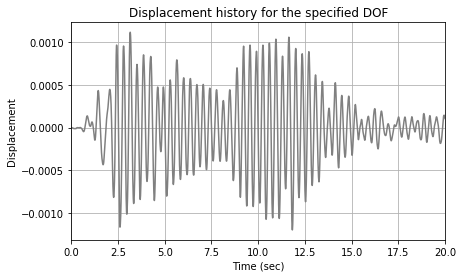

```python
fig = NodalDispPLT(displacement[0,:], T, ninc, ylabel = "Displacement")
```

### References

Wilson, Edward L. Three Dimensional Static and Dynamic Analysis Of Structures. Computers & Structures Inc, 1995.

The following cell just changes the Notebook format

```python
from IPython.core.display import HTML
def css_styling():
    styles = open('./nb_style.css', 'r').read()
    return HTML(styles)
css_styling()
```